# mpathr

## Obtaining response rates

### response_rate function

Some common operations that are done on Experience Sampling Methodology (ESM) data have to do with the participants’ response rate. We provide a function `response_rate` that calculates the response_rate per participant for the entire duration of the study, or for a specific time frame.

This function takes as argument a `valid_col`, that takes a logical column that stores whether the beep was answered by the participant, or not, as well as a `participant_col`, that identifies each separate participant.

We will show how to use this function with the `example_data`, that contains data from the same study as the `example_basic.csv` file, but after some cleaning.

```r
example_data
```

```
#> # A tibble: 1,980 × 47
#>    participant code       questionnaire  scheduled           sent
#>          <int> <chr>      <chr>          <dttm>              <dttm>
#>  1           2 !bxxm dqfu main_question… 2024-04-24 08:00:57 2024-04-24 08:00:59
#>  2           2 !bxxm dqfu main_question… 2024-04-24 09:25:44 2024-04-24 09:25:45
#>  3           2 !bxxm dqfu main_question… 2024-04-24 11:14:18 2024-04-24 11:14:20
#>  4           2 !bxxm dqfu main_question… 2024-04-24 12:58:05 2024-04-24 12:58:06
#>  5           2 !bxxm dqfu main_question… 2024-04-24 14:19:51 2024-04-24 14:19:52
#>  6           2 !bxxm dqfu main_question… 2024-04-24 15:43:05 2024-04-24 15:43:06
#>  7           2 !bxxm dqfu main_question… 2024-04-24 17:12:03 2024-04-24 17:12:04
#>  8           2 !bxxm dqfu main_question… 2024-04-24 18:07:23 2024-04-24 18:07:25
#>  9           2 !bxxm dqfu main_question… 2024-04-24 20:01:21 2024-04-24 20:01:22
#> 10           2 !bxxm dqfu main_question… 2024-04-24 21:00:14 2024-04-24 21:00:17
#> # ℹ 1,970 more rows
#> # ℹ 42 more variables: start <dttm>, stop <dttm>, phone_server_offset <dbl>,
#> #   obs_n <int>, day_n <int>, obs_n_day <int>, answered <lgl>, bpm_day <dbl>,
#> #   gender <int>, gender_string <chr>, age <chr>, life_satisfaction <dbl>,
#> #   neuroticism <dbl>, slider_happy <int>, slider_sad <int>,
#> #   slider_angry <int>, slider_relaxed <int>, slider_anxious <int>,
#> #   slider_energetic <int>, slider_tired <int>, location_index <int>, …
```

```r
response_rates <- response_rate(
  data = example_data,
  valid_col = answered,
  participant_col = participant
)
```

```
#> Calculating response rates for the entire duration of the study.
```

The function returns a data frame with:

- The `participant` column, as specified in `participant_col`
- The `number_of_beeps` used to calculate the response rate.
- The `response_rate` column, which is the proportion of valid responses (specified in `valid_col`) per participant.

The output of this function can further be used to identify participants with low response rates:

```r
response_rates[response_rates$response_rate < 0.5,]
```

```
#> # A tibble: 3 × 3
#>   participant number_of_beeps response_rate
#>         <int>           <int>         <dbl>
#> 1           2             110         0.418
#> 2          16             110         0.318
#> 3          20             110         0.436
```

We could also be interested in seeing the participants’ response rate during a specific period of time (for example, if we think a participant’s compliance significantly dropped a certain date). In this case, we should supply the function with the (otherwise optional) argument `time_col`, that should contain times stored as ‘POSIXct’ objects, and specify the date period that we are interested in (in the format ‘yyyy-mm-dd’ or ‘yyyy/mm/dd’):

```r
response_rates_after_15 <- response_rate(
  data = example_data,
  valid_col = answered,
  participant_col = participant,
  time_col = sent,
  period_start = '2024-05-15'
)
```

```
#> Calculating response rates starting from date: 2024-05-15
```

This will return the participant’s response rate after the 15th of May 2024.

```r
response_rates_after_15
```

```
#> # A tibble: 5 × 3
#>   participant number_of_beeps response_rate
#>         <int>           <int>         <dbl>
#> 1          16              55        0.0364
#> 2          17              55        0.691
#> 3          18             110        0.818
#> 4          19             110        0.636
#> 5          20             110        0.436
```

### plot_response_rate function

We also suggest a way to plot the participant response rates, to identify patterns like response rates dropping over time. For this, we provide the `plot_response_rate` function.

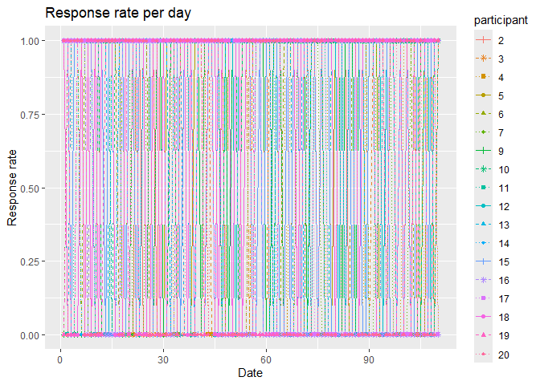

```r
plot_response_rate(
  data = example_data,
  time_col = sent,
  participant_col = participant,
  valid_col = answered
)
```

Note that the resulting plot can be further customized using the `ggplot2` package.

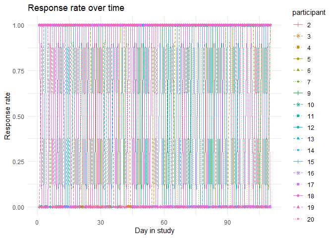

```r
library(ggplot2)

plot_response_rate(
  data = example_data,
  time_col = sent,
  participant_col = participant,
  valid_col = answered
) +
  theme_minimal() +
  ggtitle('Response rate over time') +
  xlab('Day in study')
```